# Covid Cases Exploration

Shira Wild, Maayan Aviram and Noa Radin

### Exploration of the `covid_cases` dataframe

```r
# Loading the dataframe `covid_cases`
covid_cases <- read_rds(here::here("data", "covid_cases.rds"))
```

First, let’s explore the dataset different variables

```r
# Exploring the dataset covid_cases variables
glimpse(covid_cases)
```

```
## Rows: 26,125
## Columns: 5
## $ Date            <date> 2020-01-21, 2020-01-21, 2020-01-21, 2020-01-21, 2020-~
## $ State           <chr> "AK", "AZ", "CA", "CO", "HI", "ID", "MT", "NM", "NV", ~
## $ Region          <chr> "West", "West", "West", "West", "West", "West", "West"~
## $ Daily_new_cases <dbl> 0, 0, 0, 0, 0, 0, 0, 0, 0, 0, 0, 1, 0, 0, 0, 0, 0, 0, ~
## $ Daily_new_death <dbl> 0, 0, 0, 0, 0, 0, 0, 0, 0, 0, 0, 0, 0, 0, 0, 0, 0, 0, ~
```

| Feature | Type | Description |
| --- | --- | --- |
| **Date** | Date | The reported date |
| **State** | Character | The state in the USA |
| **Region** | Character | the Region in the USA |
| **Daily_new_cases** | Double | The amount of new covid cases |
| **Daily_new_death** | Double | The amount of new death cases |

We can see that each record represents covid information for a specific date in USA states.

Now we will explore the dataset by calculating statistics on its variables

```r
# Five highest amounts of daily new cases
max_daily_new_cases <- covid_cases%>%
  arrange(desc(Daily_new_cases))
head(max_daily_new_cases, 5)
```

```
## # A tibble: 5 x 5
##   Date       State Region Daily_new_cases Daily_new_death
##   <date>     <chr> <chr>            <dbl>           <dbl>
## 1 2020-12-16 CA    West             53711             293
## 2 2021-01-02 CA    West             53341             386
## 3 2021-01-09 CA    West             52636             695
## 4 2020-12-17 CA    West             52281             379
## 5 2020-12-27 CA    West             50141             237
```

The highest amount of new covid cases for a day is 53,711 and was reported for the date 16/12/2020 in the state CA and West Region.

```r
#Five highest amounts of daily new deaths
max_daily_new_deaths <- covid_cases%>%
  arrange(desc(Daily_new_death))
head(max_daily_new_deaths, 5)
```

```
## # A tibble: 5 x 5
##   Date       State Region  Daily_new_cases Daily_new_death
##   <date>     <chr> <chr>             <dbl>           <dbl>
## 1 2021-02-12 OH    Midwest            1756            2559
## 2 2021-04-07 OK    Midwest            1764            1716
## 3 2021-02-04 IN    Midwest            2359            1518
## 4 2021-02-13 OH    Midwest            1862            1204
## 5 2021-02-25 CA    West               4965            1114
```

The highest amount of new covid deaths for a day is 2,559 and was reported for the date 12/02/2021 in the state OH and MidWest Region.

```r
# Find the first state that was exposed to covid

bigger_than_0 <- covid_cases%>%
  filter(Daily_new_cases>0)

bigger_than_0_state <- head(bigger_than_0, 1)$State

cat(paste0("The state that was first exposed to covid is ", bigger_than_0_state))
```

```
## The state that was first exposed to covid is WA
```

```r
# Average new death cases for a day for each state in a descending order
av_dead_state <- covid_cases%>%
  group_by(State)%>%
  summarise(Average_death = round(mean(Daily_new_death),2))%>%
  arrange(desc(Average_death)) %>% head(5)

av_dead_state
```

```
## # A tibble: 5 x 2
##   State Average_death
##   <chr>         <dbl>
## 1 CA            131.
## 2 TX            106.
## 3 NY             90.0
## 4 FL             77.7
## 5 PA             57.4
```

The highest average of death cases per day is 131 and was reported for the state CA.

```r
# Average new cases per a day for each state in a descending order
 av_cases_state <- covid_cases%>%
  group_by(State)%>%
  summarise(Average_cases = round(mean(Daily_new_cases),3))%>%
  arrange(desc(Average_cases)) %>% head(5)
av_cases_state
```

```
## # A tibble: 5 x 2
##   State Average_cases
##   <chr>         <dbl>
## 1 CA            7760.
## 2 TX            5303.
## 3 FL            4901.
## 4 NY            4392.
## 5 IL            2912.
```

The highest average of daily new cases per day is 7760 and was reported for the state CA. We can see that CA is also the state with the highest amount of daily new cases per a day and the state with the highest death average per day, as we saw earlier. A possible explanation for that evidence is that CA is one of the most populous countries in the USA.

```r
# Average new cases per a day for each region in a descending order
av_cases_region <- covid_cases%>%
  group_by(Region)%>%
  summarise(Average_cases = round(mean(Daily_new_cases),2))%>%
  arrange(desc(Average_cases))
av_cases_region
```

```
## # A tibble: 5 x 2
##   Region    Average_cases
##   <chr>             <dbl>
## 1 South            1689.
## 2 Midwest          1166.
## 3 West             1151.
## 4 Northwest        1041.
## 5 Territory          70.5
```

The South Region holds the highest amount of average new cases per a day.

#### Visualisation of the CovidCases dataframe

First, we will display the amount of covid cases per state on the USA map:

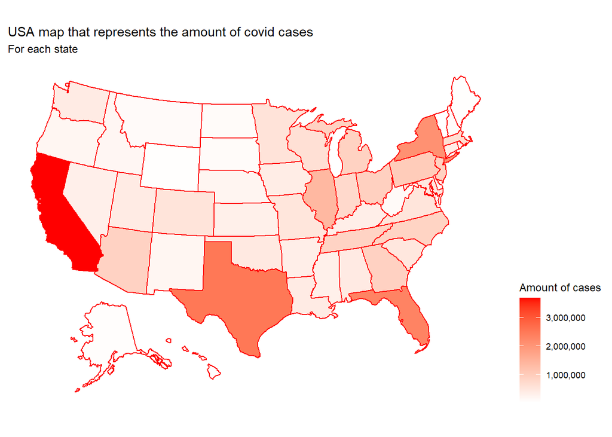

```r
grouped_by <- covid_cases%>%
  group_by(State)%>%
  summarise(amount_of_covid_cases = round(sum(Daily_new_cases),3))

colnames(grouped_by)[1]<-"state"

plot_usmap(data = grouped_by, values = "amount_of_covid_cases", color = "red") +
  scale_fill_continuous(low = "white", high= "red",name = "Amount of cases", label = scales::comma) +
  theme(legend.position = "right") + theme(legend.position = "right") +
     labs(title = "USA map that represents the amount of covid cases", subtitle = "For each state")
```

We can see that the state with the highest amount of covid cases is California, this insight makes sense since California is the the most populous country in the United States. Other countries that stand out in the map in terms of amount of covid cases are Texas, Florida and New-York.

```r
# Data preperations for the first plot

# Comupute the total amount of new cases per each date and region in the USA
cases_per_date_region <- covid_cases%>%
  group_by(Date, Region)%>%
    summarise(Sum_of_cases = sum(Daily_new_cases),.groups='drop')

# Comupute the accumulate amount of new cases grouped by region
summed_cases <- cases_per_date_region%>%
  group_by(Region)%>%
  mutate(cumulative_cases = cumsum(Sum_of_cases))
```

Now, let’s visualize the amount of new covid cases over time for each region:

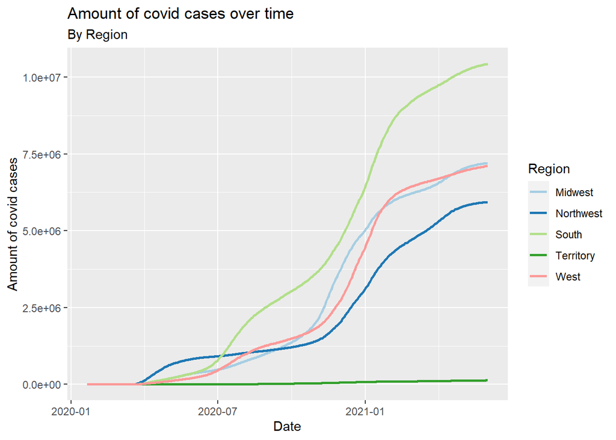

```r
# First plot - The amount of covid cases according over time

ggplot(summed_cases, aes(x = Date, y = cumulative_cases, color = as.factor(Region))) +
  geom_line(size = 1)+
    scale_color_brewer(palette="Paired")+
   labs(title = "Amount of covid cases over time",subtitle="By Region", x= "Date", y = "Amount of covid cases" ,color = "Region")
```

This plot describes the cumulative amount of new cases by regions. When the slope of the line is extreme it might indicate a wave of illness. For example, around July 2020 we can see an extreme change in the slope of the South line and from this we can conclude that from this point of time the morbidity has pounced. In addition to that, we can see that the South, as we mentioned before, is the region with the highest amount of new cases per a day and it achieves the highest amount of total new cases.

Now, let’s explore the histogram of new cases over time separated by the different regions:

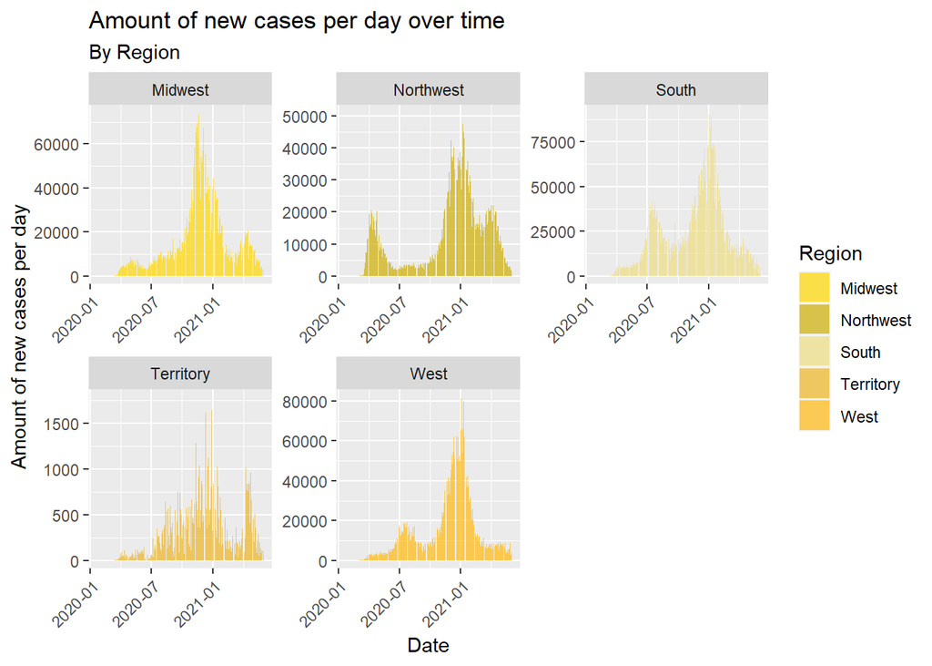

```r
# Second plot - The amount of new cases over time by region

# Create a copy for covid_cases dataset including only positive values for the column "Daily_new_cases"

copy_covid_cases<-covid_cases%>%filter(Daily_new_cases>=0)

# Create the plot
ggplot(data = copy_covid_cases, aes(x = Date, y = Daily_new_cases, fill = as.factor(Region))) +
  geom_bar(alpha = 0.7, stat="identity")+
  theme(axis.text.x = element_text(angle = 45,hjust=1)) +
  facet_wrap(~Region, scales = "free")+
    scale_fill_manual(values = c("gold", "gold3", "lightgoldenrod2", "goldenrod2", "darkgoldenrod1", "darkgoldenrod4"))+
   labs(title = "Amount of new cases per day over time", subtitle = "By Region", x= "Date", y = "Amount of new cases per day",fill = "Region")
```

Let’s explore the histograms of death cases over time separated by the different regions:

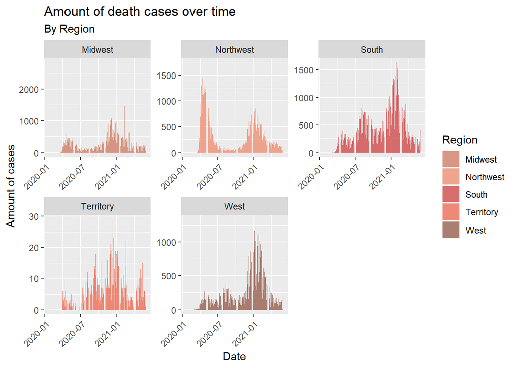

```r
# Third plot - The amount of death cases over time by region

# Create a copy for covid_cases dataframe including only positive values for the column "Daily_new_deaths"
copy_covid_cases_d<-covid_cases%>%filter(Daily_new_death>=0)

# Create the plot
ggplot(data = copy_covid_cases_d, aes(x = Date, y = Daily_new_death, fill = as.factor(Region))) +
  geom_bar(alpha = 0.7, stat="identity")+theme(axis.text.x = element_text(angle = 45,hjust=1)) +
  theme(axis.text.x = element_text(angle = 45,hjust=1)) +
  facet_wrap(~Region, scales = "free")+
    scale_fill_manual(values = c("salmon3", "salmon2", "brown3", "tomato2", "salmon4"))+
   labs(title = "Amount of death cases over time", subtitle = "By Region", x= "Date", y = "Amount of cases",fill = "Region")
```

This plot describes the different distributions of new covid death cases per day during the time for each one of the regions.

We saw that the South Region was significantly affected by the covid, so let’s explore the average amount of new cases in the states of the South region.

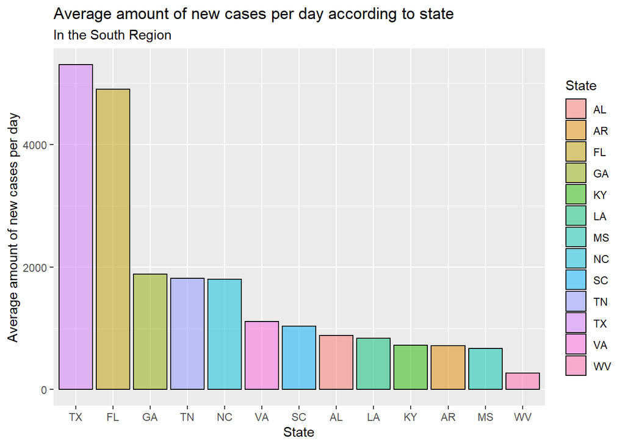

```r
# Fourth plot -  The average amount of new cases per a day in the South region

# Compute the average deaths for each state in the South Region in a descending order
south_filtered <- covid_cases%>%
  filter(Region == "South")%>%
  group_by(State)%>%
  summarise(Average_cases = round(mean(Daily_new_cases),3))

# Create the plot
ggplot(south_filtered, aes(x = reorder(State,-Average_cases), y = Average_cases, fill = as.factor(State)))+
  geom_bar(alpha = 0.5, stat ="identity", color = "black")+
   labs(title = "Average amount of new cases per day according to state", subtitle = "In the South Region", x= "State", y = "Average amount of new cases per day",fill = "State")
```

We can see that the states Texas and Florida are the states with the highest amount of average covid cases in the South Region. This insight makes sense since Texas is the seccond most populated country in the USA and Florida is the third most populated country in the USA.

### Exploration of `sum_cases` dataframe: the summarized data of covid cases

```r
# Loading the dataset sum_cases
sum_cases <- read_rds(here::here("data", "sum_cases.rds"))
```

Let’s explore the different variables of the dataset:

```r
# Exploring the dataset sum_cases variables
glimpse(sum_cases)
```

```
## Rows: 475
## Columns: 8
## $ Date            <date> 2020-01-21, 2020-01-24, 2020-01-25, 2020-01-26, 2020-~
## $ Daily_confirmed <dbl> 1, 1, 1, 2, 1, 1, 1, 3, 1, 0, 2, 0, 1, 0, 4, 5, 18, 15~
## $ Total_confirmed <dbl> 1, 2, 3, 5, 6, 7, 8, 11, 12, 12, 14, 14, 15, 15, 19, 2~
## $ Daily_deaths    <dbl> 0, 0, 0, 0, 0, 0, 0, 0, 0, 0, 0, 0, 0, 0, 0, 1, 1, 4, ~
## $ Total_deaths    <dbl> 0, 0, 0, 0, 0, 0, 0, 0, 0, 0, 0, 0, 0, 0, 0, 1, 2, 6, ~
## $ Daily_recovered <dbl> 0, 0, 0, 0, 0, 0, 0, 0, 0, 3, 2, 1, 0, 0, 0, 1, 2, 0, ~
## $ Total_recovered <dbl> 0, 0, 0, 0, 0, 0, 0, 0, 0, 3, 5, 6, 6, 6, 6, 7, 9, 9, ~
## $ Active          <dbl> 1, 2, 3, 5, 6, 7, 8, 11, 12, 9, 9, 8, 9, 9, 13, 16, 31~
```

[output not shown]

We can see that each record in the dataset represents a specific date and the amount of confirmed/deaths/recovered/active in this date.

```r
# Top 5 days with the maximal amount of death cases

max_daily_new_deaths <- sum_cases%>%
  arrange(desc(Daily_deaths)) %>% select(Date ,Daily_deaths)
head(max_daily_new_deaths, 5)
```

```
##         Date Daily_deaths
## 1 2021-02-12         5369
## 2 2021-02-04         4955
## 3 2021-01-20         4137
## 4 2021-01-12         4013
## 5 2021-01-07         3916
```

The highest amount of total death cases per a day is 5369 and was reported for the date 12/02/2021.

```r
#Top 5 days with the maximal amount of new covid cases

max_daily_new_cases <- sum_cases%>%
  arrange(desc(Daily_confirmed))
head(max_daily_new_cases, 5)
```

```
##         Date Daily_confirmed Total_confirmed Daily_deaths Total_deaths
## 1 2021-01-08          274627        20764232         3555       349106
## 2 2021-01-02          258867        19438731         2252       331563
## 3 2021-01-07          250394        20489605         3916       345551
## 4 2021-01-09          247540        21011772         3437       352543
## 5 2020-12-18          226197        16681000         2681       296548
##   Daily_recovered Total_recovered  Active
## 1          116632        13259949 7155177
## 2          185546        12361387 6745781
## 3          119175        13143317 7000737
## 4          133129        13393078 7266151
## 5          103229        10394286 5990166
```

The highest amount of total new cases per a day is 274,627 and was reported for the date 08/01/2021.

```r
# Creating new columns for "month","year" and the format of "month-year" based on the date

seperated_date_sum_cases <- sum_cases
seperated_date_sum_cases$month <- format(seperated_date_sum_cases$Date, "%m")
seperated_date_sum_cases$year <- format(seperated_date_sum_cases$Date, "%y")
seperated_date_sum_cases$month_and_year <- paste(format(seperated_date_sum_cases$Date, "%y"),format(seperated_date_sum_cases$Date, "%m"), sep = "-")
```

```r
# Top 5 months with the highest amount of total new cases

# Compute the total sum of new cases for each month and year
new_cases_grouped_by <- seperated_date_sum_cases %>%
  group_by(month_and_year) %>%
  summarise(sum_total = sum(Daily_confirmed,na.rm = TRUE),.groups="drop")%>%
  arrange(desc(sum_total))
head(new_cases_grouped_by, 5)
```

```
## # A tibble: 5 x 2
##   month_and_year sum_total
##   <chr>              <dbl>
## 1 20-12            5899923
## 2 21-01            5621254
## 3 20-11            4191064
## 4 21-02            2099624
## 5 20-07            1895595
```

The month with the highest amount of total new cases is December 2020.

```r
# Top 5 months with the highest amount of total death cases

# Compute the total sum of new death cases for each month and year
deaths_grouped_by <- seperated_date_sum_cases %>%
  group_by(month_and_year) %>%
  summarise(total_death_cases = sum(Daily_deaths,na.rm = TRUE),.groups="drop")%>%
  arrange(desc(total_death_cases))
head(deaths_grouped_by, 5)
```

```
## # A tibble: 5 x 2
##   month_and_year total_death_cases
##   <chr>                      <dbl>
## 1 21-01                      91276
## 2 20-12                      73675
## 3 21-02                      68081
## 4 20-04                      53330
## 5 20-05                      40822
```

The month with the higest amount of total death cases is January 2021.

```r
# Top 5 months with highest amount of average active cases
active_grouped_by <- seperated_date_sum_cases %>%
  group_by(month_and_year) %>%
  summarise(average_active_cases = mean(Active,na.rm = TRUE),.groups="drop")%>%
  arrange(desc(average_active_cases))
head(active_grouped_by, 5)
```

```
## # A tibble: 5 x 2
##   month_and_year average_active_cases
##   <chr>                         <dbl>
## 1 21-01                      7471456.
## 2 21-02                      7141019.
## 3 20-12                      5752277.
## 4 21-03                      5080936.
## 5 21-04                      3901844.
```

The month with the highest average of active cases is January 2021.

#### Visualisation of the sum_cases dataframe

First, let’s explore the relationship between the amount of active cases and the amount of recovery cases from covid:

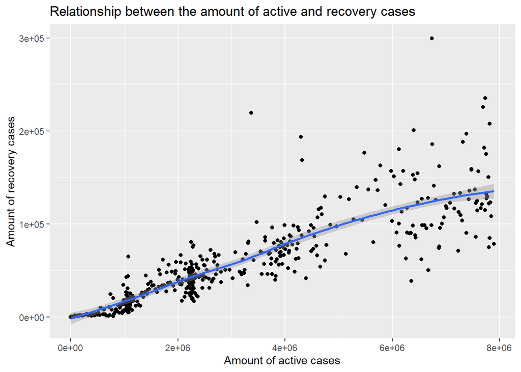

```r
# First plot - connection between the amount of active patients to the amount of recovered patients
filtered_sum_cases <- sum_cases %>% filter(Daily_recovered<=300000)

# Create the plot
ggplot(filtered_sum_cases,
mapping = aes(x = Active, y = Daily_recovered)) +
geom_point()+
geom_smooth()+
labs(title = "Relationship between the amount of active and recovery cases",  x = "Amount of active cases", y = "Amount of recovery cases")
```

We can see that there is a connection between the amount of active patients to the amount of recovered patients - as the number of active patients in a day increases, so does the number of people recovering from the disease. A possible explanation for this evidence is that usually it takes 2 weeks on average to recover from covid. Therefore, it makes sense that the amount of active patients and the amount of recovered patients are proportional.

```r
# Calculate the total amount of active cases and the total amount of new cases per month and year

group_by_monthyear <- seperated_date_sum_cases %>%
  group_by(month_and_year) %>% summarise(
    ActivesAmount = sum(Active), DeathCasesAmount = sum(Daily_deaths))

# Create a pivoted dataframe
pivoted_monthyear <- group_by_monthyear%>%
  pivot_longer(cols = c("ActivesAmount", "DeathCasesAmount") , names_to = "active_or_death", values_to = "amount")
```

Now, let’s visualize the total amount of active and death cases for each month over time

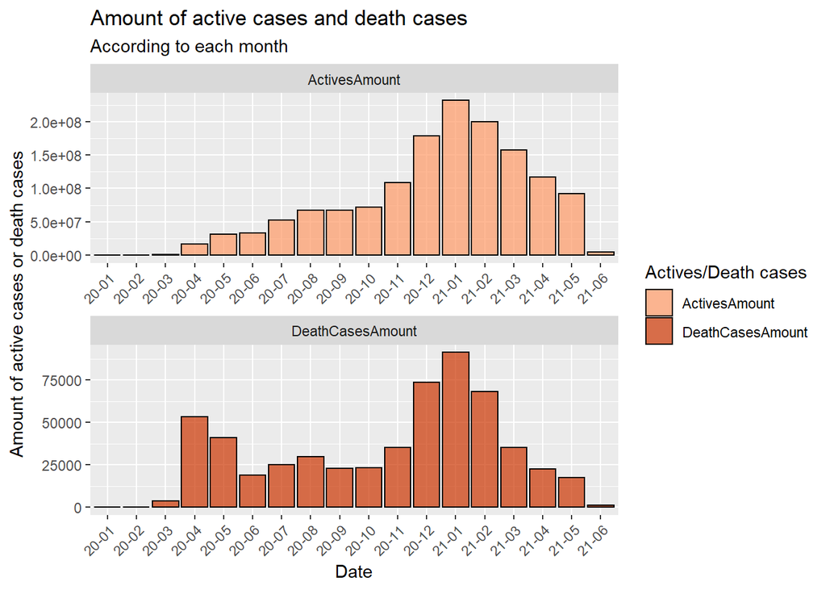

```r
# Seccond plot - Amount of new covid cases and death cases over time

# Create the plot
ggplot(data = pivoted_monthyear, aes(x = month_and_year, y=amount, fill = as.factor(active_or_death))) +
  geom_bar(alpha = 0.7,stat="identity", color = "black")+
  facet_wrap(~active_or_death,nrow=2, scales = "free") +
    scale_fill_manual(values = c("#FF9966", "#CC3300")) +
   theme(axis.text.x = element_text(angle = 45,hjust=1)) +
    #scale_x_discrete(guide = guide_axis(check.overlap = TRUE)) +
   labs(title = "Amount of active cases and death cases", subtitle = "According to each month" , x= "Date", y =        "Amount of active cases or death cases",fill = "Actives/Death cases")
```

This plot can describe the spread and the progress of the covid disease: It can be seen that in the beginning of the covid disease (around March 2020) an increase has began in the number of active patients: The number of active patients per month increases from month to month and receives its peek at January 2021 - as we saw earlier this is the month with the highest amount of average active cases. After January 2021 we can see a descent trend in the number of active cases per month, until May 2021. We can assume that this descent trend is a result of the immunization policy or a result of people awareness of the disease.

Another interesting insight is that there is a correspondence between the advance of the amount of active cases and the amount of death cases per a month: For example, both of them receives their peek in January 2021 and then there is a descent in both of them. This also makes sense, when the amount of active cases increase we except to see as a result a growth in the number of death cases and same in the opposite direction.

Let’s visualize the amount of daily new confirmed and recovered patients over time:

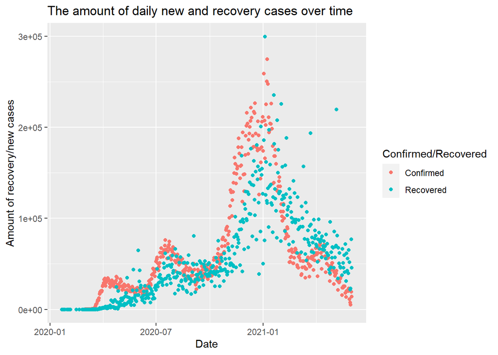

```r
# Third plot - The amount of new covid and recovery cases over time

filtered<- filter(sum_cases, Daily_recovered<=300000)

colors <- c("Confirmed" = "#ff9933", "Recovered" = "#0066cc")

# Create the plot
ggplot(data = filtered, mapping = aes(x=Date)) +
  geom_point(aes(y=Daily_confirmed,color="Confirmed"))+
  geom_point(aes(y=Daily_recovered,color="Recovered"))+
   labs(title = "The amount of daily new and recovery cases over time", x= "Date", y = "Amount of recovery/new cases",color = "Confirmed/Recovered")
```

We can see a general trend of increase in the number of confirmed patients and recovered patients over time until January 2021. After January 2021 there is a decline in the amount of new confirmed patients and the recovered patients. As we expected, we can see that the amount of new confirmed cases and the amount of recovered patients increase and decrease together respectively and this insight reinforces the conclusion from the first plot. In addition to that, at the begining of the epidemic we can see 2 relatively small waves, and then towards December 2020 it can be seen that there is a large wave that has reached its peak in January 2021. As we expected, we can see that the amount of new confirmed cases and the amount of recovered patients increase and decrease together respectively.